# GSS R: installation and first exploration

GSS

Package Installatoin

ECDF

QQ plots

Published

September 5, 2024

```r
if (!require(gssr)) {
  if (!require(remotes)){
    install.packages("remotes")
  }
  remotes::install_github("kjhealy/gssr")
}
```

- **L3 MIASHS**
- **[Université Paris Cité](https://www.u-paris.fr)**
- Année 2024-2025
- [Course Homepage](https://stephane-v-boucheron.fr/courses/scidon)
- [Moodle](https://moodle.u-paris.fr/course/view.php?id=6143)

**Objectives**

### Install and use package `gssr`

We work again with General Social Survey (GSS) data.

We take advantage of `R` package [`gssr`](https://kjhealy.github.io/gssr/)

```r
if (!require(gssr)) {
  if (!require(remotes)){
    install.packages("remotes")
  }
  remotes::install_github("kjhealy/gssr")
}
```

[interactive chart not shown]

### Get data for year 2018

The GSS is carried out every two years. It offers both *cross-sectional* data and *panel* data.

Package `gssr` offers a simple way to retrieve yearly data.

```r
df_2018 <- gssr::gss_get_yr(2018)
```

```
Fetching: https://gss.norc.org/documents/stata/2018_stata.zip
```

### Inspect the data

- How many observations?
- How many variables?
- Are the data tidy/messy?

```r
dim(df_2018)
```

```
[1] 2348 1069
```

### Numerical summaries for `age` and `agekdbrn`

The `2018` data provide (among too many other things) columns named `age` abd `agekdbrn`. Get numerical summaries about these two columns.

```r
df_2018 |>
  dplyr::select(age, agekdbrn) |>
  skimr::skim() |>
  skimr::yank("numeric")
```

**Variable type: numeric**

| skim_variable | n_missing | complete_rate | mean | sd | p0 | p25 | p50 | p75 | p100 | hist |
| --- | --- | --- | --- | --- | --- | --- | --- | --- | --- | --- |
| age | 7 | 1.00 | 48.97 | 18.06 | 18 | 34 | 48 | 63 | 89 | ▇▇▇▆▃ |
| agekdbrn | 682 | 0.71 | 24.30 | 5.74 | 12 | 20 | 23 | 28 | 51 | ▃▇▃▁▁ |

Thanks to `gssr`, you can get meta-information about the columns

```r
?aged
?agekdbrn
?sex
```

### How is `sex` encoded? Is it worth recoding it?

```r
df_2018 |>
  mutate(sex=as_factor(sex)) |>
  skimr::skim(sex) |>
  skimr::yank("factor")
```

**Variable type: factor**

| skim_variable | n_missing | complete_rate | ordered | n_unique | top_counts |
| --- | --- | --- | --- | --- | --- |
| sex | 0 | 1 | FALSE | 2 | fem: 1296, mal: 1052, don: 0, iap: 0 |

### Histogram and density plots for `age` distribution/facet by `sex`

```r
p_age <- df_2018 |>
  mutate(sex=as_factor(sex)) |>
  ggplot() +
  aes(x=age) +
  facet_wrap(~ sex, )

q_age <- df_2018 |>
  mutate(sex=as_factor(sex)) |>
  ggplot() +
  aes(x=age)
```

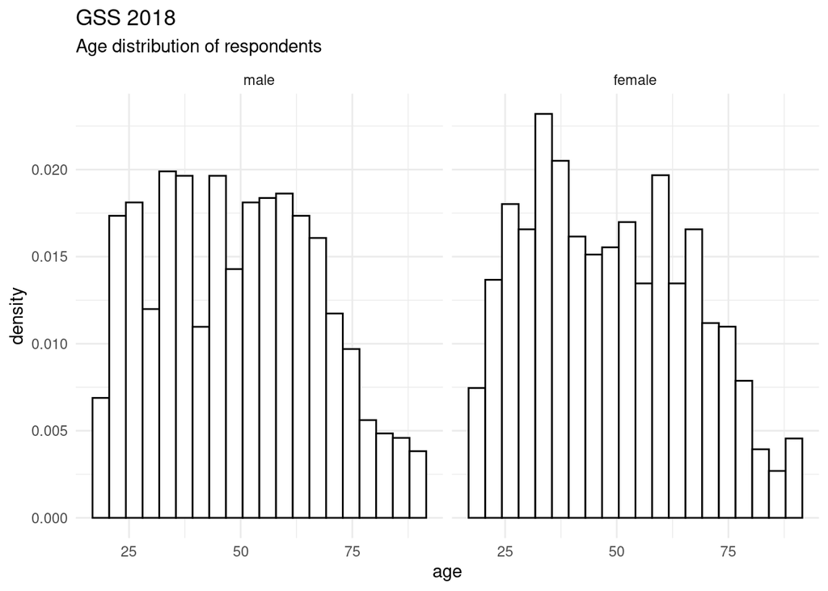

```r
p_age +
  geom_histogram(aes(y=after_stat(density)),
                 fill="white",
                 color="black",
                 bins=20) +
  labs(
    title="GSS 2018",
    subtitle = "Age distribution of respondents"
  )
```

- Play with number of bins
- Spot the irregular behavior of the histograms
- Something special at the right edge of both histograms

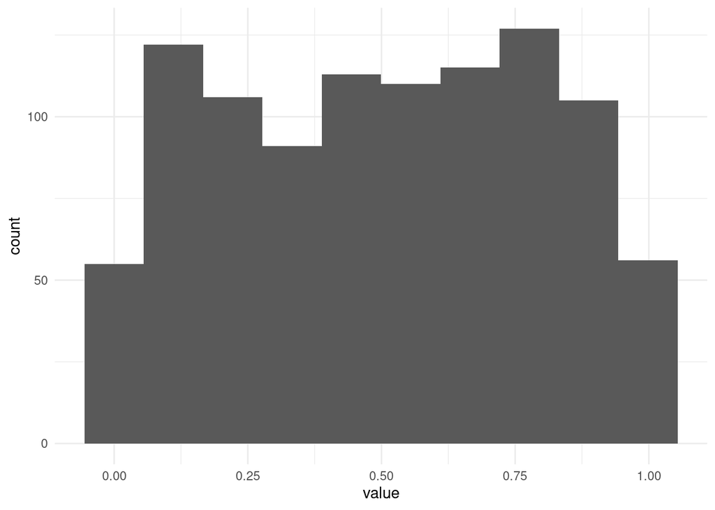

```r
enframe(x=runif(1000))  |>
  ggplot() +
  aes(x=value) +
  geom_histogram(bins=10)
```

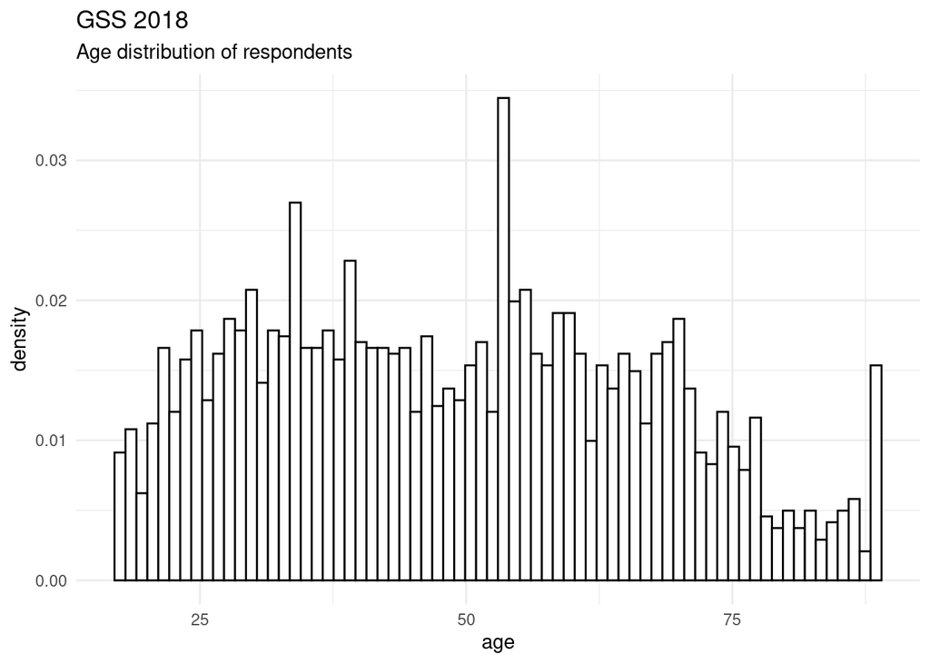

```r
q_age +
  geom_histogram(aes(y=after_stat(density)),
                 fill="white",
                 color="black",
                 bins=70) +
  labs(
    title="GSS 2018",
    subtitle = "Age distribution of respondents"
  )
```

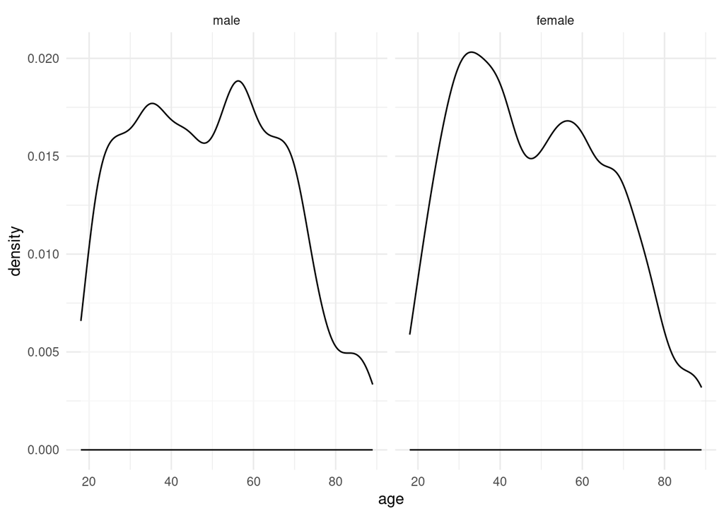

```r
p_age +
  stat_density(aes(y=after_stat(density)),
               fill="white",
               alpha=.5,
               color="black",
               bw = "sj",
               adjust = 1
               )
```

- Play with arguments `bw` and `adjust` of `stat_density`
- Same comments

### Compare *sample* `age` distribution with *population* `age` distribution

```r
knitr::include_url("https://perspective.usherbrooke.ca/bilan/servlet/BMPagePyramide/USA/2018/?", height=600)
```

Sherbrooke University offers visual information about the age structure of population of a wide range of countries.

Following demographic usage, the age structure is presented through an age pyramid.

Note that an age pyramid is a special kind of histogram

[interactive chart not shown]

### Parallel boxplots of `age` with respect to `sex`

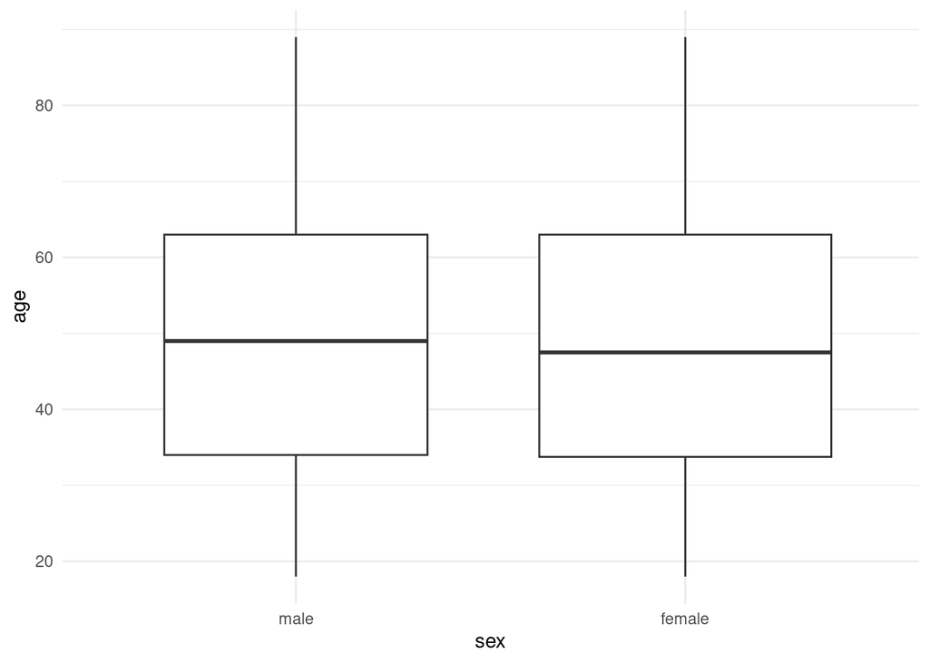

```r
df_2018 |>
  mutate(sex=as_factor(sex)) |>
  ggplot() +
  aes(y=age, x=sex) +
  geom_boxplot(varwidth = T) +
  xlab("sex")
```

### QQplot comparing sample male and female age distributions

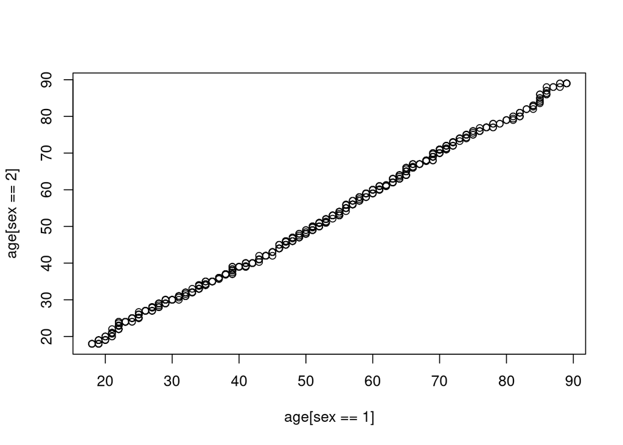

```r
with(df_2018,
     qqplot(x=age[sex==1], y=age[sex==2]))
```

### Make your own qqplot

```r
cdf_age_2018_1 <- ecdf(df_2018$age[df_2018$sex==1])

tb <- df_2018 |>
  dplyr::filter(sex==2) |>
  dplyr::select(age) |>
  mutate(Fn=rank(age, ties.method = "max")/n()) |>
  distinct() |>
  arrange(age)

eqf_age_2018_2 <- with(tb,
     stepfun(x=Fn, y=c(age, max(age)), right = T, f = 1))
```

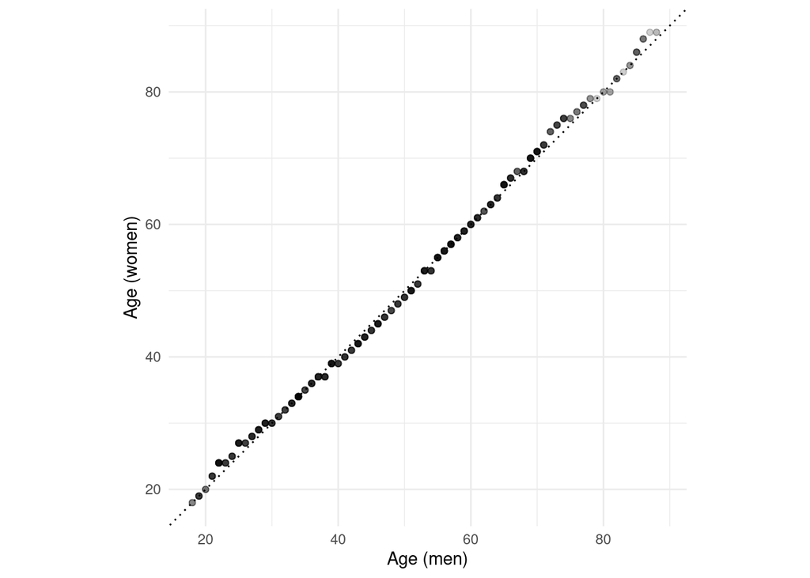

```r
filter(df_2018, sex==1) |>
  ggplot() +
  aes(x=age, y=eqf_age_2018_2(cdf_age_2018_1(age))) +
  geom_point(alpha=.1, fill="white") +
  geom_abline(intercept = 0, slope=1, linetype="dotted") +
  coord_fixed() +
  xlab("Age (men)") +
  ylab("Age (women)")
```

```r
# data(gss_all)
```

```r
data(gss_dict)
```

```r
gss_dict |>
  filter(variable=="age")
```

```
# A tibble: 1 × 13
    pos variable label      missing var_doc_label value_labels var_text years
  <int> <chr>    <chr>        <int> <chr>         <chr>        <chr>    <list>
1    90 age      age of re…     769 age of respo… [89] 89 or … 13. Res… <tibble>
# ℹ 5 more variables: var_yrtab <list>, var_ballots <list>, col_type <chr>,
#   var_type <chr>, var_na_codes <chr>
```

```r
# gss_which_years(gss_all, c("age", "agekdbrn"))
```

### Working with `gss_sub`

```r
data("gss_sub")

gss_sub |>
  glimpse()
```

```
Rows: 72,390
Columns: 20
$ year     <dbl+lbl> 1972, 1972, 1972, 1972, 1972, 1972, 1972, 1972, 1972, 197…
$ id       <dbl> 1, 2, 3, 4, 5, 6, 7, 8, 9, 10, 11, 12, 13, 14, 15, 16, 17, 18…
$ ballot   <dbl+lbl> NA(i), NA(i), NA(i), NA(i), NA(i), NA(i), NA(i), NA(i), N…
$ age      <dbl+lbl> 23, 70, 48, 27, 61, 26, 28, 27, 21, 30, 30, 56, 54, 49, 4…
$ race     <dbl+lbl> 1, 1, 1, 1, 1, 1, 1, 1, 2, 2, 2, 2, 2, 2, 2, 2, 1, 1, 1, …
$ sex      <dbl+lbl> 2, 1, 2, 2, 2, 1, 1, 1, 2, 2, 2, 1, 1, 2, 1, 1, 1, 2, 2, …
$ degree   <dbl+lbl> 3, 0, 1, 3, 1, 1, 1, 3, 1, 1, 1, 0, 0, 0, 0, 1, 1, 0, 3, …
$ padeg    <dbl+lbl>     0,     0,     0,     3,     0,     3,     3,     3,  …
$ madeg    <dbl+lbl> NA(i),     0,     0,     1,     0,     4,     1,     1,  …
$ relig    <dbl+lbl> 3, 2, 1, 5, 1, 1, 2, 3, 1, 1, 1, 1, 1, 1, 1, 1, 1, 1, 1, …
$ polviews <dbl+lbl> NA(i), NA(i), NA(i), NA(i), NA(i), NA(i), NA(i), NA(i), N…
$ fefam    <dbl+lbl> NA(i), NA(i), NA(i), NA(i), NA(i), NA(i), NA(i), NA(i), N…
$ vpsu     <dbl+lbl> NA(i), NA(i), NA(i), NA(i), NA(i), NA(i), NA(i), NA(i), N…
$ vstrat   <dbl+lbl> NA(i), NA(i), NA(i), NA(i), NA(i), NA(i), NA(i), NA(i), N…
$ oversamp <dbl+lbl> 1, 1, 1, 1, 1, 1, 1, 1, 1, 1, 1, 1, 1, 1, 1, 1, 1, 1, 1, …
$ formwt   <dbl+lbl> NA(y), NA(y), NA(y), NA(y), NA(y), NA(y), NA(y), NA(y), N…
$ wtssall  <dbl+lbl> 0.4446, 0.8893, 0.8893, 0.8893, 0.8893, 0.4446, 0.4446, 0…
$ wtssps   <dbl+lbl> 0.6631963, 0.9173700, 0.8974125, 1.0663408, 0.9443237, 0.…
$ sampcode <dbl+lbl> NA(i), NA(i), NA(i), NA(i), NA(i), NA(i), NA(i), NA(i), N…
$ sample   <dbl+lbl> 1, 1, 1, 1, 1, 1, 1, 1, 1, 1, 1, 1, 1, 1, 1, 1, 1, 1, 1, …
```

```r
gss_sub |>
  head()
```

```
# A tibble: 6 × 20
  year         id ballot      age    race    sex     degree  padeg   madeg
  <dbl+lbl> <dbl> <dbl+lbl>   <dbl+> <dbl+l> <dbl+l> <dbl+l> <dbl+l> <dbl+lbl>
1 1972          1 NA(i) [iap] 23     1 [whi… 2 [fem… 3 [bac… 0 [les… NA(i) [iap]
2 1972          2 NA(i) [iap] 70     1 [whi… 1 [mal… 0 [les… 0 [les…     0 [les…
3 1972          3 NA(i) [iap] 48     1 [whi… 2 [fem… 1 [hig… 0 [les…     0 [les…
4 1972          4 NA(i) [iap] 27     1 [whi… 2 [fem… 3 [bac… 3 [bac…     1 [hig…
5 1972          5 NA(i) [iap] 61     1 [whi… 2 [fem… 1 [hig… 0 [les…     0 [les…
6 1972          6 NA(i) [iap] 26     1 [whi… 1 [mal… 1 [hig… 3 [bac…     4 [gra…
# ℹ 11 more variables: relig <dbl+lbl>, polviews <dbl+lbl>, fefam <dbl+lbl>,
#   vpsu <dbl+lbl>, vstrat <dbl+lbl>, oversamp <dbl+lbl>, formwt <dbl+lbl>,
#   wtssall <dbl+lbl>, wtssps <dbl+lbl>, sampcode <dbl+lbl>, sample <dbl+lbl>
```

```r
gss_sub |>
  dplyr::select(-id, -year) |>
  summarise(across(everything(), n_distinct)) |>
  pivot_longer(cols = everything(), names_to="name_col", values_to = "n_distct") |>
  arrange(n_distct) |>
  filter(n_distct < 15) |>
  left_join(gss_dict, by=c("name_col"="variable"))
```

```
# A tibble: 11 × 14
   name_col n_distct   pos label     missing var_doc_label value_labels var_text
   <chr>       <int> <int> <chr>       <int> <chr>         <chr>        <chr>
 1 sex             3   125 responde…     112 respondents … [1] male; [… 23. Cod…
 2 race            4   126 race of …     107 race of resp… [1] white; … 24. Wha…
 3 ballot          5  6072 ballot u…   21875 ballot used … [1] ballot … 1659. B…
 4 fefam           5   784 better f…   37259 better for m… [1] strongl… 252. No…
 5 oversamp        5  6078 weights …       0 weights for … [1] not 198… None
 6 degree          6    98 r's high…     196 r's highest … [0] less th… 19. If …
 7 padeg           6    99 father's…   17881 father's hig… [0] less th… 20. If …
 8 madeg           6   100 mothers …    8971 mothers high… [0] less th… 21. If …
 9 polviews        8   227 think of…    9672 think of sel… [1] extreme… 67a. We…
10 sample         11  6077 sampling…    4032 sampling fra… [1] 1960 sa… 1664. T…
11 relig          14   336 r's reli…     437 r's religiou… [1] protest… 104. Wh…
# ℹ 6 more variables: years <list>, var_yrtab <list>, var_ballots <list>,
#   col_type <chr>, var_type <chr>, var_na_codes <chr>
```

### Education through generations

What kind of information do we get through variables `degree` and `padeg`?

```r
?degree
?padeg
```

### Compute contingency table for `degree` and `padeg`

```r
tab_degree_padeg <- gss_sub |>
  dplyr::select(degree, padeg) |>
  mutate(across(everything(), as_factor)) |>
  table()
```

```r
tab_degree_padeg |>
  chisq.test()
```

```
    Pearson's Chi-squared test

data:  tab_degree_padeg
X-squared = NaN, df = 256, p-value = NA
```

### Visualize contingency table for `degree` and `padeg`

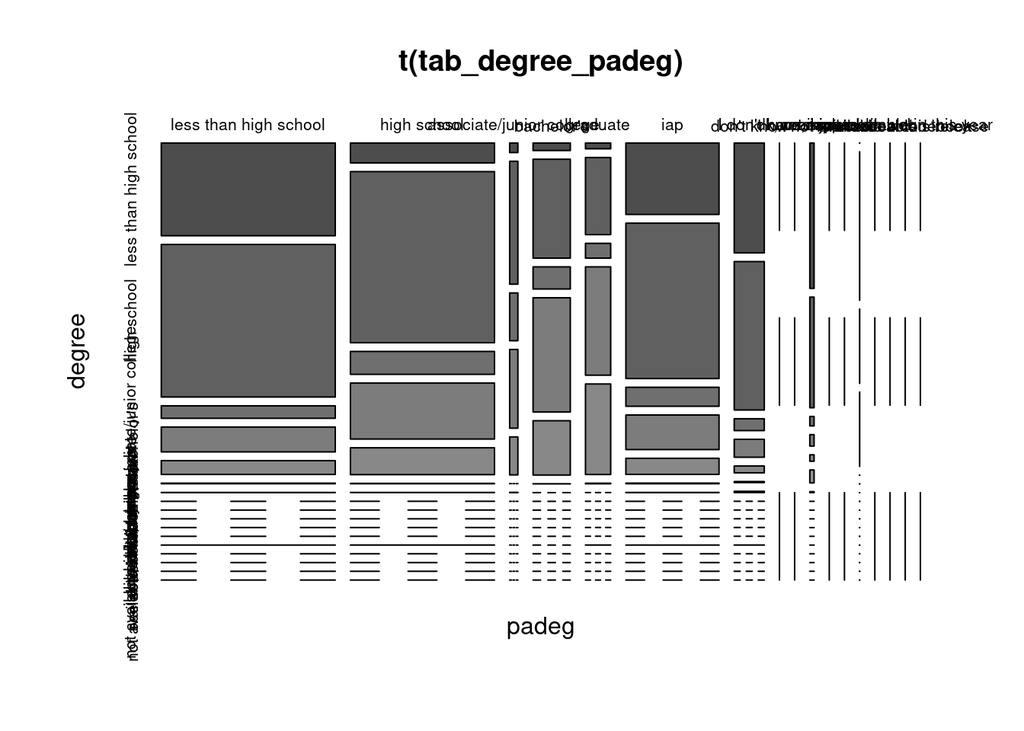

```r
tab_degree_padeg |>
  t() |>
  mosaicplot(color = T)
```

### Rearrange the levels of `degree` and `padeg`